# Module-8-Zombie

# Zombie

```r
library(curl)
f <- f <- curl("https://raw.githubusercontent.com/fuzzyatelin/fuzzyatelin.github.io/master/AN597_Fall17/zombies.csv")
d <- read.csv(f, header = TRUE, sep = ",", stringsAsFactors = FALSE)
head(d)
```

```
##   id first_name last_name gender   height   weight zombies_killed
## 1  1      Sarah    Little Female 62.88951 132.0872              2
## 2  2       Mark    Duncan   Male 67.80277 146.3753              5
## 3  3    Brandon     Perez   Male 72.12908 152.9370              1
## 4  4      Roger   Coleman   Male 66.78484 129.7418              5
## 5  5      Tammy    Powell Female 64.71832 132.4265              4
## 6  6    Anthony     Green   Male 71.24326 152.5246              1
##   years_of_education                           major      age
## 1                  1                medicine/nursing 17.64275
## 2                  3 criminal justice administration 22.58951
## 3                  1                       education 21.91276
## 4                  6                  energy studies 18.19058
## 5                  3                       logistics 21.10399
## 6                  4                  energy studies 21.48355
```

# Zombie[1]

```r
h <- d$height
meanh <- mean(h)
meanh
```

```
## [1] 67.6301
```

above is the mean height of the population, or at least how I calculated it. I am a little confused as to why we need to set up a variable and why we casn’t just use the mean tool

```r
lh<-length(d$height) #this is 1000
nh<-5 #we'll randomly choose samples of 5, like in the module
dummy_height <- NULL #this is our dummy variable to hold each sample
for (i in 1:k){
    dummy_height[[i]]<-sample(d$height,size=nh,replace=FALSE)
}
head(dummy_height)
```

[output not shown]

```r
pop_height <- NULL
for (i in 1:k){
    pop_height[i] <- mean(dummy_height[[i]])
}
mean(pop_height)
```

[output not shown]

this is the the way to sample you tolled us to

```r
pop_v <- function(h) {
    sum((h - mean(h))^2)/(length(h))
}
pop_v(h)
```

```
## [1] 18.55861
```

```r
pop_sd <- function(h) {
    sqrt(pop_v(h))
}
pop_sd(h)
```

```
## [1] 4.30797
```

above is the poulation SD for height

```r
w <- d$weight
meanw <- mean(w)
meanw
```

```
## [1] 143.9075
```

above is the mean weight how I calculated it

```r
lw<-length(d$weight) #this is 1000
nw<-5 #we'll randomly choose samples of 5, like in the module
dummy_weight <- NULL #this is our dummy variable to hold each sample
for (i in 1:k){
    dummy_weight[[i]]<-sample(d$weight,size=nh,replace=FALSE)
}
head(dummy_weight)
```

[output not shown]

this is how you calculated it

```r
pop_weight <- NULL
for (i in 1:k){
    pop_weight[i] <- mean(dummy_weight[[i]])
}
mean(pop_weight)
```

[output not shown]

this is how you said to calculate the mean

```r
pop_v <- function(w) {
    sum((w - mean(w))^2)/(length(w))
}
pop_sd <- function(w) {
    sqrt(pop_v(w))
}
pop_sd(w)
```

```
## [1] 18.39186
```

above is the population SD for weight

```r
a <- d$age
meana <- mean(a)
meana
```

```
## [1] 20.04696
```

above is the mean age that I calculated

```r
la<-length(d$age) #this is 1000
na<-5 #we'll randomly choose samples of 5, like in the module
dummy_age <- NULL #this is our dummy variable to hold each sample
for (i in 1:k){
    dummy_age[[i]]<-sample(d$age,size=n,replace=FALSE)
}
head(dummy_age)
```

[output not shown]

```r
pop_age <- NULL
for (i in 1:k){
    pop_age[i] <- mean(dummy_age[[i]])
}
mean(pop_age)
```

[output not shown]

this is how you told us to calculate mean

```r
pop_v <- function(a) {
    sum((a - mean(a))^2)/(length(a))
}
pop_sd <- function(a) {
    sqrt(pop_v(a))
}
pop_sd(a)
```

```
## [1] 2.963583
```

above is the population SD for age

```r
z <- d$zombies_killed
meanz <- mean(z)
meanz
```

```
## [1] 2.992
```

above is the mean number of zombies killed I calculated

```r
la<-length(d$zombies_killed) #this is 1000
na<-5 #we'll randomly choose samples of 5, like in the module
dummy_zombies_killed <- NULL #this is our dummy variable to hold each sample
for (i in 1:k){
    dummy_zombies_killed[[i]]<-sample(d$zombies_killed,size=n,replace=FALSE)
}
head(dummy_zombies_killed)
```

[output not shown]

```r
pop_zombies_killed <- NULL
for (i in 1:k){
    pop_zombies_killed[i] <- mean(dummy_zombies_killed[[i]])
}
mean(pop_zombies_killed)
```

[output not shown]

this is how you told us to calculate it

```r
pop_v <- function(z) {
    sum((z - mean(z))^2)/(length(z))
}
pop_sd <- function(z) {
    sqrt(pop_v(z))
}
pop_sd(z)
```

```
## [1] 1.747551
```

above is the population SD for number of zombies killed

```r
y <- d$years_of_education
meany <- mean(y)
meany
```

```
## [1] 2.996
```

above is the mean of the years of education that I calculated

```r
ly<-length(d$years_of_education) #this is 1000
ny<-5 #we'll randomly choose samples of 5, like in the module
dummy_years_of_education <- NULL #this is our dummy variable to hold each sample
for (i in 1:k){
    dummy_years_of_education[[i]]<-sample(d$years_of_education,size=n,replace=FALSE)
}
head(dummy_years_of_education)
```

[output not shown]

```r
pop_years_of_education<- NULL
for (i in 1:k){
    pop_years_of_education[i] <- mean(dummy_years_of_education[[i]])
}
mean(pop_years_of_education)
```

[output not shown]

this is the mean that you told us to calculate

```r
pop_v <- function(y) {
    sum((y - mean(y))^2)/(length(y))
}
pop_sd <- function(y) {
    sqrt(pop_v(y))
}
pop_sd(y)
```

```
## [1] 1.675704
```

above is the population SD for years of education

# Zombie[2]

```r
ph <- ggplot(data = d, aes(x = gender, y =height))
ph <- ph + geom_boxplot()
ph <- ph + theme(axis.text.x = element_text(angle = 90))
ph <- ph + ylab("height")
ph
```

[output not shown]

```r
pw <- ggplot(data = d, aes(x = gender, y =weight))
pw <- pw + geom_boxplot()
pw <- pw + theme(axis.text.x = element_text(angle = 90))
pw <- pw + ylab("weight")
pw
```

[output not shown]

```r
pa <- ggplot(data = d, aes(x = gender, y =age))
pa <- pa + geom_boxplot()
pa <- pa + theme(axis.text.x = element_text(angle = 90))
pa <- pa + ylab("age")
pa
```

[output not shown]

```r
pz <- ggplot(data = d, aes(x = gender, y =zombies_killed))
pz <- pz + geom_boxplot()
pz <- pz + theme(axis.text.x = element_text(angle = 90))
pz <- pz + ylab("number of zombies killed")
pz
```

[output not shown]

```r
py <- ggplot(data = d, aes(x = gender, y =years_of_education))
py <- py + geom_boxplot()
py <- py + theme(axis.text.x = element_text(angle = 90))
py <- py + ylab("years of education")
py
```

[output not shown]

# Zombies[3]

```r
psh <- ggplot(data = d, aes(x = age, y = height))
psh <- psh + xlab("age") + ylab("height")
psh <- psh + geom_point()
psh <- psh + theme(legend.position = "bottom", legend.title = element_blank())
age_height <- psh + geom_smooth(method = "lm")
age_height
```

[output not shown]

```r
psw <- ggplot(data = d, aes(x = age, y = weight))
psw <- psw + xlab("age") + ylab("weight")
psw <- psw + geom_point()
psw <- psw + theme(legend.position = "bottom", legend.title = element_blank())
age_weight <- psw + geom_smooth(method = "lm")
age_weight
```

[output not shown]

# Zombie[4]

```r
minh <- min(d$height)
minh
```

```
## [1] 54.14948
```

```r
maxh <- max(d$height)
maxh
```

```
## [1] 80.5298
```

here I took the min and hax for height so I could make my histograms

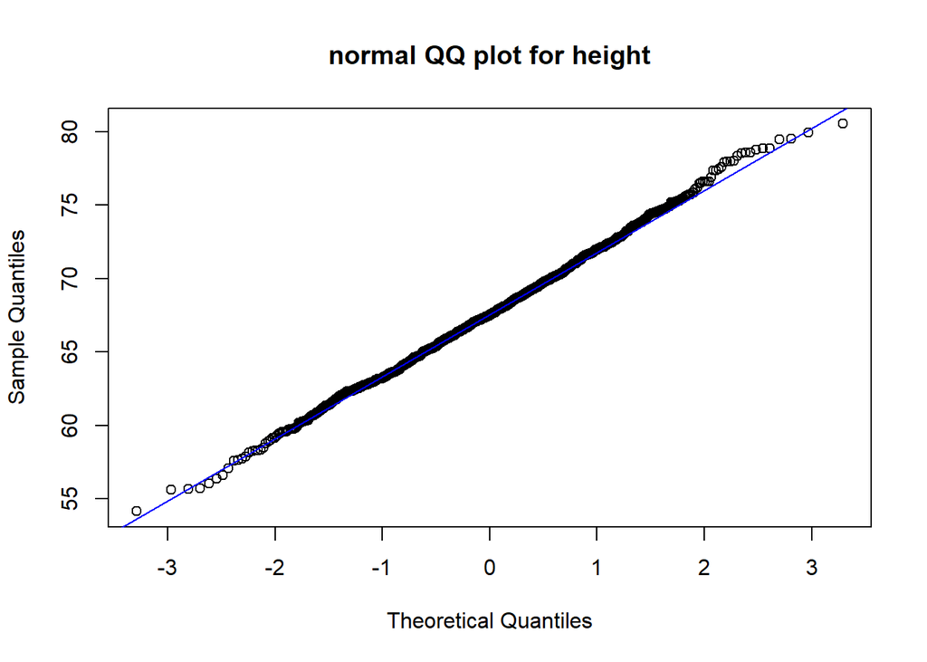

```r
qqnorm(d$height, main="normal QQ plot for height")
qqline(d$height, col="blue")
```

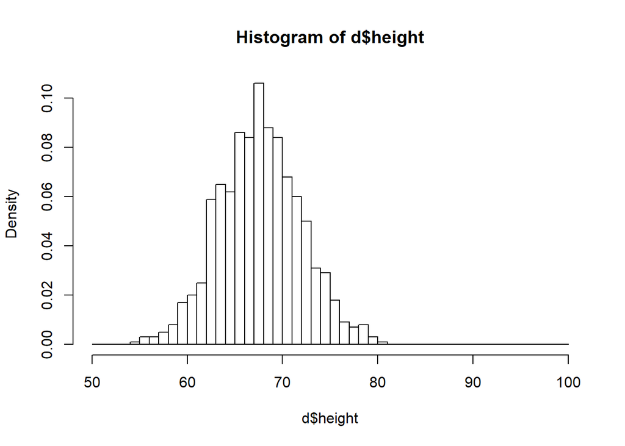

```r
hist(d$height, breaks = seq(from =50, to =100, by=1), probability= TRUE)
```

The distrabutioin above for height looks normal

```r
minw <- min(d$weight)
minw
```

```
## [1] 90.29148
```

```r
maxw <- max(d$weight)
maxw
```

```
## [1] 210.7895
```

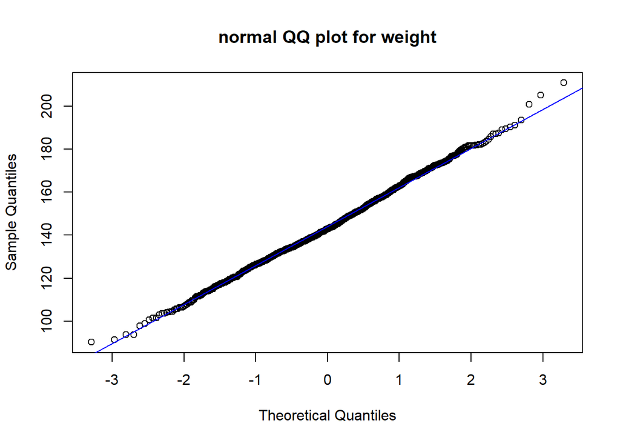

```r
qqnorm(d$weight, main="normal QQ plot for weight")
qqline(d$weight, col="blue")
```

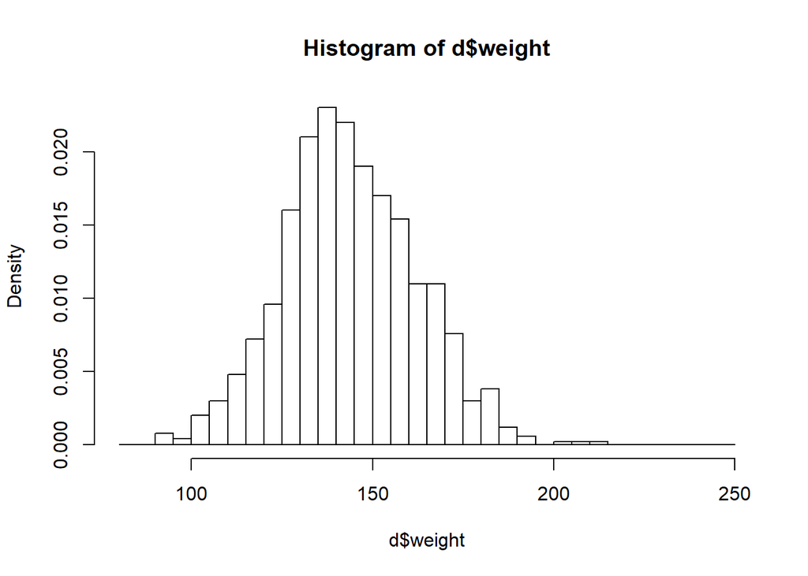

```r
hist(d$weight, breaks = seq(from =80, to =250, by=5), probability= TRUE)
```

The distrabutioin above for weight looks normal

```r
mina <- min(d$age)
mina
```

```
## [1] 10.66381
```

```r
maxa <- max(d$age)
maxa
```

```
## [1] 29.59488
```

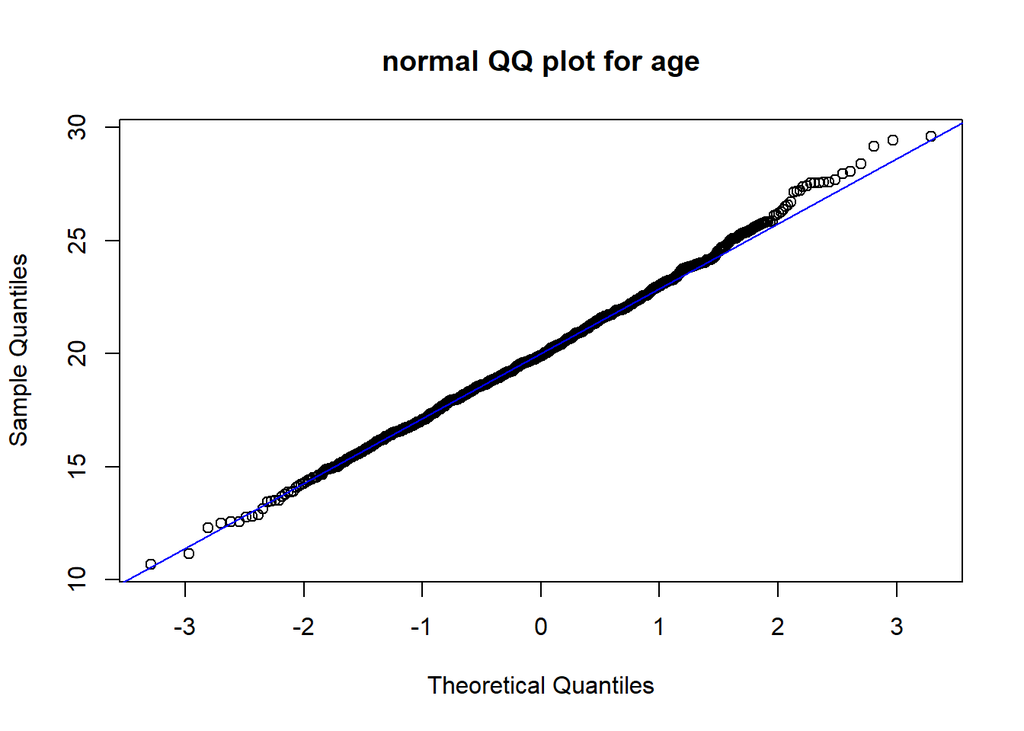

```r
qqnorm(d$age, main="normal QQ plot for age")
qqline(d$age, col="blue")
```

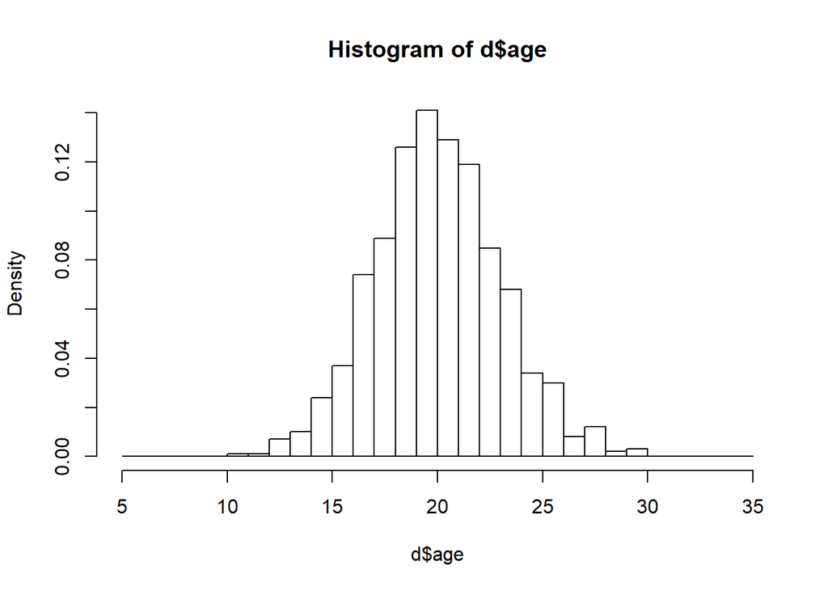

```r
hist(d$age, breaks = seq(from =5, to =35, by=1), probability= TRUE)
```

The distrabutioin above for age looks normal

```r
minz <- min(d$zombies_killed)
minz
```

```
## [1] 0
```

```r
maxz <- max(d$zombies_killed)
maxz
```

```
## [1] 11
```

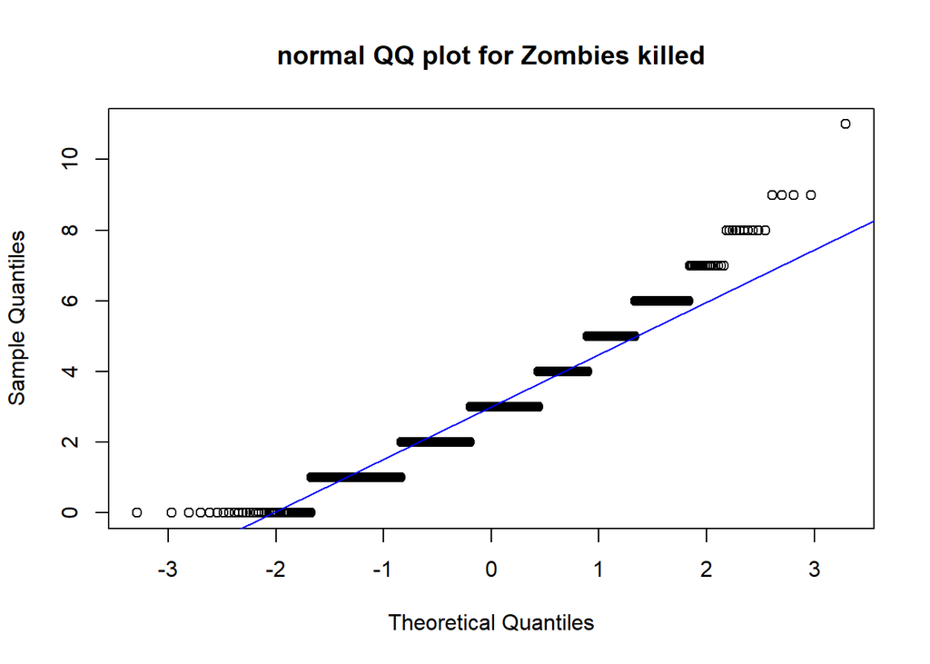

```r
qqnorm(d$zombies_killed, main="normal QQ plot for Zombies killed")
qqline(d$zombies_killed, col="blue")
```

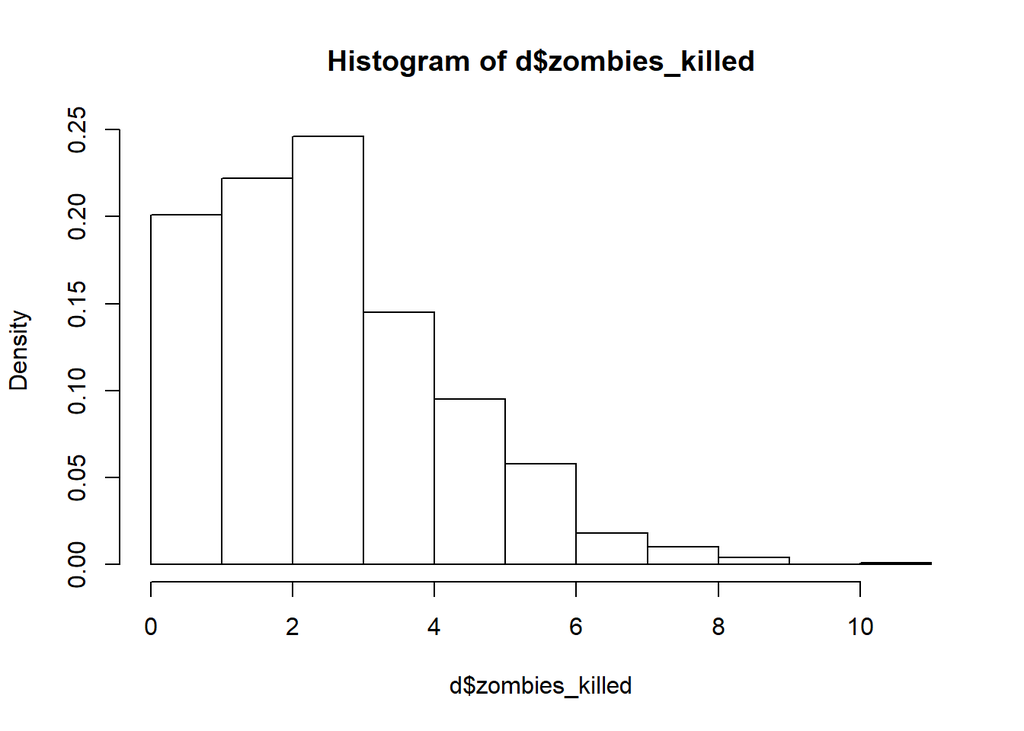

```r
hist(d$zombies_killed, breaks = seq(from =0, to =11, by=1), probability= TRUE)
```

```r
minz <- min(d$years_of_education)
minz
```

```
## [1] 0
```

```r
maxz <- max(d$years_of_education)
maxz
```

```
## [1] 8
```

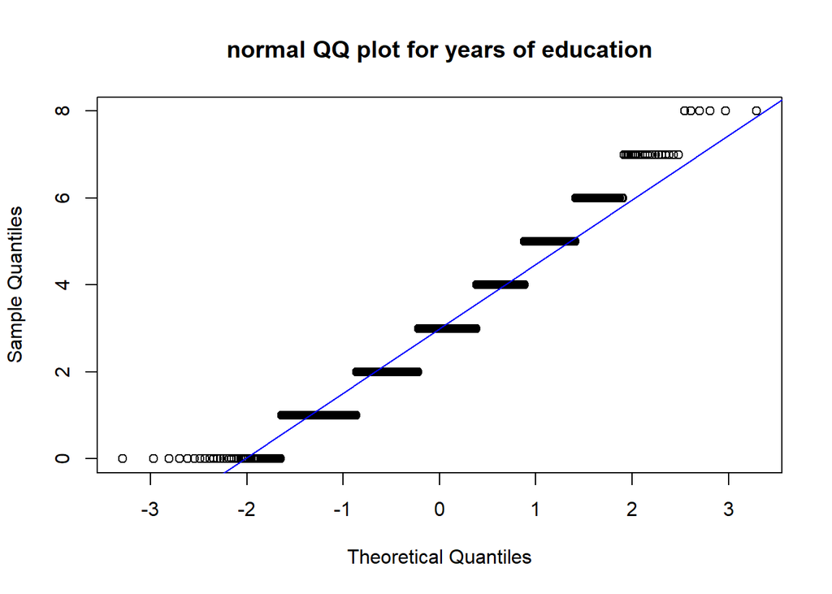

```r
qqnorm(d$years_of_education, main="normal QQ plot for years of education")
qqline(d$years_of_education, col="blue")
```

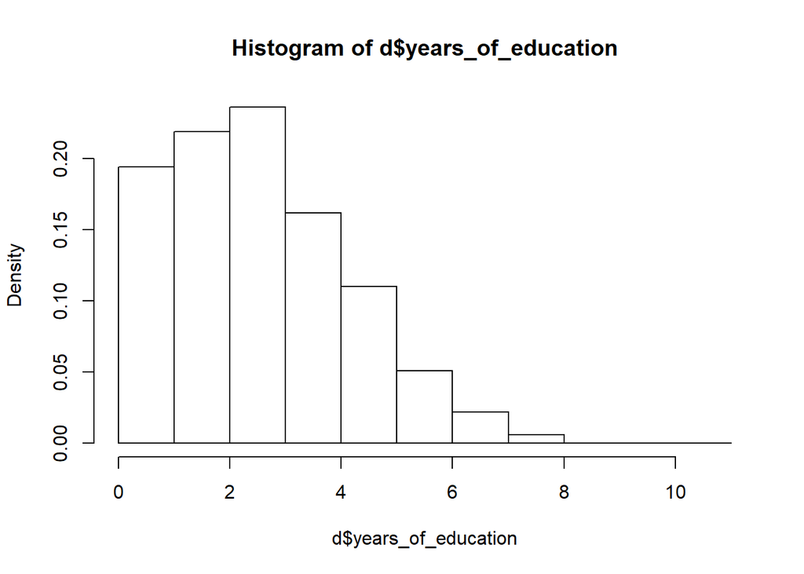

```r
hist(d$years_of_education, breaks = seq(from =0, to =11, by=1), probability= TRUE)
```

```r
samp <- d[sample(nrow(d), 30, replace = FALSE, prob = NULL),  ]
samp
```

```
##      id  first_name last_name gender   height   weight zombies_killed
## 66   66        Jose    Barnes   Male 66.52924 153.9619              3
## 325 325   Catherine      Diaz Female 70.25889 146.4168              2
## 771 771      Bonnie  Peterson Female 66.51151 123.8688              8
## 227 227       Maria   Wallace Female 62.94211 132.0677              0
## 729 729 Christopher Henderson   Male 72.78263 149.9674              2
## 534 534        John Hernandez   Male 66.13919 133.4684              4
## 374 374      Sandra Alexander Female 64.57137 135.0448              0
## 556 556   Stephanie   Bennett Female 57.85084 102.9128              4
## 273 273         Ann    Carter Female 62.65719 148.3196              2
## 719 719       Debra   Jackson Female 73.81399 159.5498              4
## 695 695       Wayne    Nguyen   Male 63.38425 129.1097              3
## 603 603    Nicholas    Parker   Male 65.07314 137.9821              3
## 777 777      Evelyn  Gonzales Female 67.01884 135.6524              4
## 656 656     Kathryn  Peterson Female 64.72491 126.4283              4
```

[output cut: 47 more lines]

above is the sample data from d

```r
samph <- samp$height
meansh <- mean(samph)
meansh
```

```
## [1] 68.21585
```

```r
sampvarh <- var(samph)
sampSDh <- sqrt(sampvarh)
sampSDh
```

```
## [1] 4.505878
```

```r
sampSEh <- sqrt(sampvarh/30)
sampSEh
```

```
## [1] 0.822657
```

```r
upperh <- qnorm( 0.95, mean=meansh, sd=sampSDh)
upperh
```

```
## [1] 75.62736
```

```r
lowerh <- qnorm( 0.05, mean=meansh, sd=sampSDh)
lowerh
```

```
## [1] 60.80434
```

```r
cih <- c(lowerh, upperh)
cih
```

```
## [1] 60.80434 75.62736
```

```r
sampw <- samp$weight
meansw <- mean(sampw)
meansw
```

```
## [1] 145.4125
```

```r
sampvarw <- var(sampw)
sampSDw <- sqrt(sampvarw)
sampSDw
```

```
## [1] 17.8064
```

```r
sampSEw <- sqrt(sampvarw/30)
sampSEw
```

```
## [1] 3.250989
```

```r
upperw <- qnorm( 0.95, mean=meansw, sd=sampSDw)
upperw
```

```
## [1] 174.7015
```

```r
lowerw <- qnorm( 0.05, mean=meansw, sd=sampSDw)
lowerw
```

```
## [1] 116.1236
```

```r
ciw <- c(lowerw, upperw)
ciw
```

```
## [1] 116.1236 174.7015
```

```r
sampa <- samp$age
meansa <- mean(sampa)
meansa
```

```
## [1] 20.41327
```

```r
sampvara <- var(sampa)
sampSDa <- sqrt(sampvara)
sampSDa
```

```
## [1] 3.015001
```

```r
sampSEa <- sqrt(sampvara/30)
sampSEa
```

```
## [1] 0.5504613
```

```r
uppera <- qnorm( 0.95, mean=meansa, sd=sampSDa)
uppera
```

```
## [1] 25.3725
```

```r
lowera <- qnorm( 0.05, mean=meansa, sd=sampSDa)
lowera
```

```
## [1] 15.45403
```

```r
cia <- c(lowera, uppera)
cia
```

```
## [1] 15.45403 25.37250
```

```r
sampz <- sample(d$zombies_killed,size=30,replace=FALSE)
meansz <- mean(sampz)
meansz

sd(sampz)

se(sampz)

set<-NULL  # sets up a dummy variable to hold our simulations
n<-15
for (i in 1:10000) {
    set[i]<-mean(sample(sampz,n,replace=TRUE))
}
quantile(set,c(0.025,0.975))
```

[output not shown]

```r
sampy <- sample(d$years_of_education,size=30,replace=FALSE)
meansy <- mean(sampy)
meansy

sd(sampy)

se(sampy)

set<-NULL  # sets up a dummy variable to hold our simulations
n<-15
for (i in 1:10000) {
    set[i]<-mean(sample(sampy,n,replace=TRUE))
}
quantile(set,c(0.025,0.975))
```

[output not shown]

# Zombie[6]

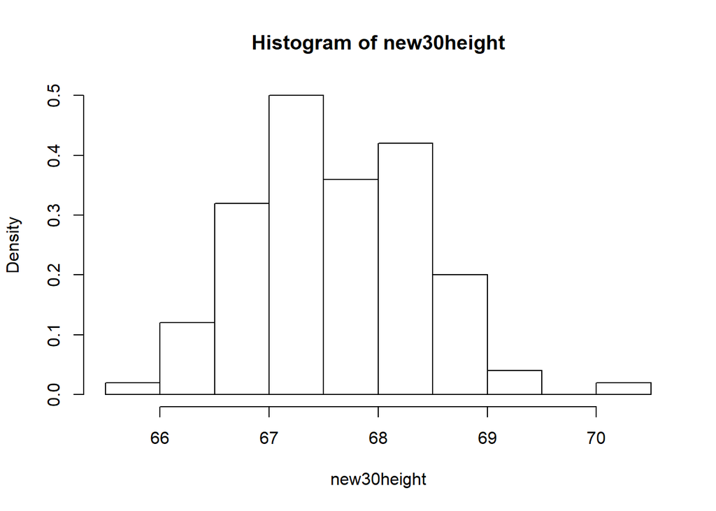

```r
new30height <- NULL
for (i in 1:100) {
    new30height[i] <- mean(sample(d$height,30))
}

hist(new30height,probability = TRUE)
```

this is the random new sample of 30 individuals 100 times for height

```r
mean(new30height)
```

```
## [1] 67.61502
```

```r
sd(new30height)
```

```
## [1] 0.747697
```

these are the mean and sd for the new samples of height

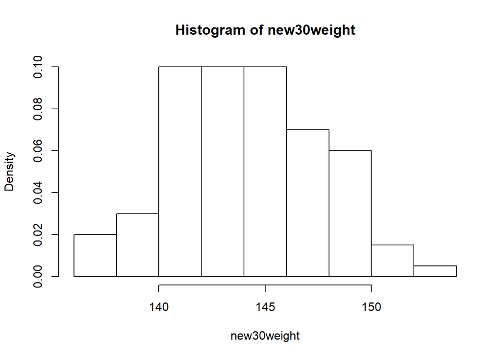

```r
new30weight <- NULL
for (i in 1:100) {
    new30weight[i] <- mean(sample(d$weight,30))
}

hist(new30weight,probability = TRUE)
```

this is the random new sample of 30 individuals 100 times for weight

```r
mean(new30weight)
```

```
## [1] 144.1453
```

```r
sd(new30weight)
```

```
## [1] 3.415342
```

these are the mean and sd for the new samples of weight

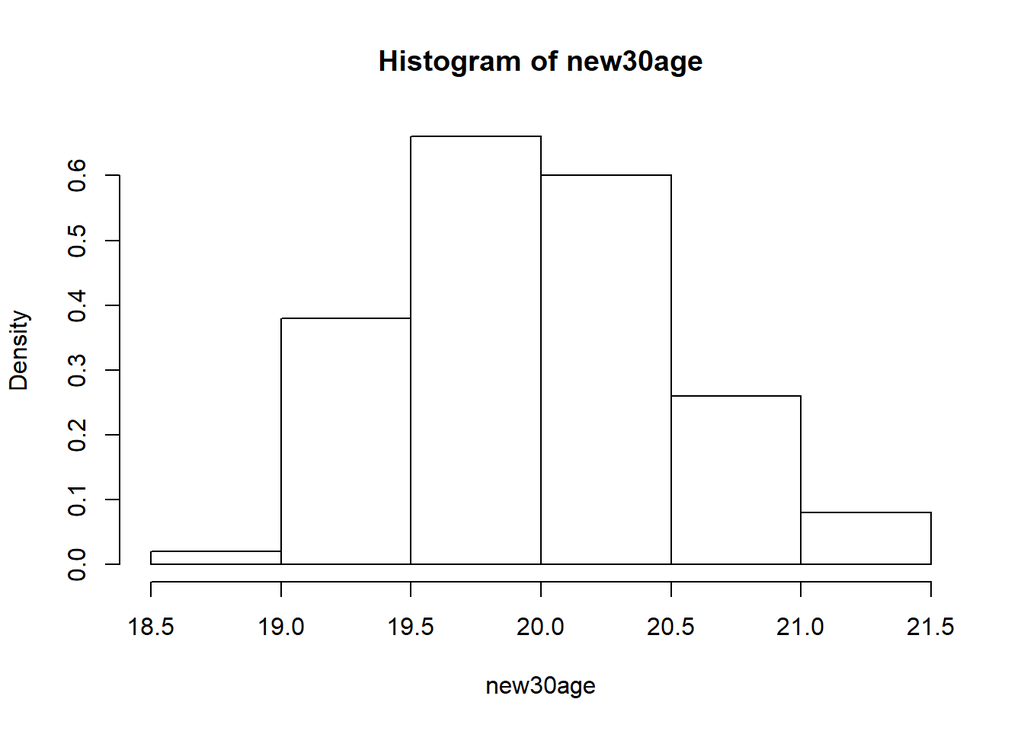

```r
new30age<-NULL
for (i in 1:100) {
    new30age[i] <- mean(sample(d$age,30))
}

hist(new30age,probability = TRUE)
```

this is the random new sample of 30 individuals 100 times for age

```r
mean(new30age)
```

```
## [1] 19.99591
```

```r
sd(new30age)
```

```
## [1] 0.5304996
```

these are the mean and sd for the new samples of age

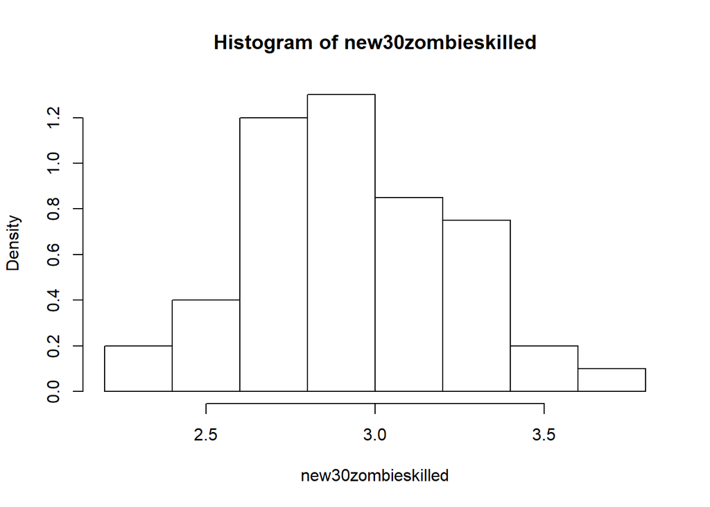

```r
new30zombieskilled<-NULL
for (i in 1:100) {
    new30zombieskilled[i] <- mean(sample(d$zombies_killed,30))
}

hist(new30zombieskilled,probability = TRUE)
```

this is the random new sample of 30 individuals 100 times for number of zombeis killed

```r
mean(new30zombieskilled)
```

```
## [1] 2.949
```

```r
sd(new30zombieskilled)
```

```
## [1] 0.307572
```

these are the mean and sd for the new samples of number of zombies killed

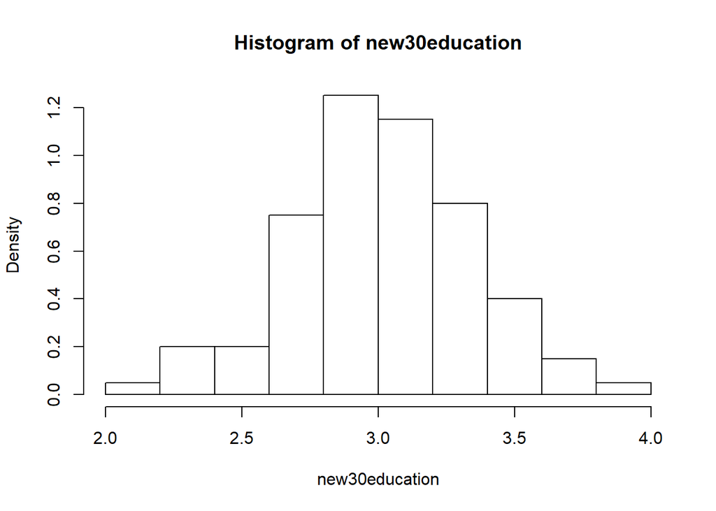

```r
new30education<-NULL
for (i in 1:100) {
    new30education[i] <- mean(sample(d$years_of_education,30))
}

hist(new30education,probability = TRUE)
```

this is the random new sample of 30 individuals 100 times for years of education

```r
mean(new30education)
```

```
## [1] 3.019
```

```r
sd(new30education)
```

```
## [1] 0.3410308
```

these are the mean and sd for the new samples of years of education these new sd are very similar to the se, they are not exact, but they are similar. all of these samples for the most part look normal more or less. Even the variables that looks like a poisson distrabutiom (the number of zombies killed and years of education) are now normal looking after taking the mean and sd of a sample 100 times.